# Final-Project-Notebook-AdultsCensus-AWS_D

### This is an academic exercise using Spark in the following:

- Using DataBricks spark-sklearn package for Spark powered grid search of Scikit Learn classifiers
- Begin exploring the pyspark MLLIB tree classifiers

#### The data used in this exercise is from the UCI Machine Learning lab. It is the well known Adult Census data. The objective is to predict the minority class, or those that make more than $50K annual salary

#### This notebook is setup in the following sections:

1) Data Load

2) Preprocessing

3) Sklearn - Further tuning of 2 best classifiers from a previous project using Spark grid search and some conceptual feature selection using Random Forest, K-means, and Locally-Linear Embedding (LLE)

4) MLlib - Proof of concept MLlib Tree classifiers (DTRee, RF, and GBT) implemented using the same dataset

```python
import os
import sys
import socket
import time

# AWS IPs start with 172.xxx.xxx.xxx
print 'SYSTEM:     ', socket.gethostname()

spark_home = os.environ.get('SPARK_HOME', None)
if not spark_home:
    raise ValueError('SPARK_HOME not set do the following')
            # Need to:
            #    $ export SPARK_HOME='<spark location>' # in .bashrc
            #    $ source .bashrc
            #    $ printenv        # to verify SPARK_HOME in environment
sys.path.insert(0, os.path.join(spark_home, 'python'))
sys.path.insert(0, os.path.join(spark_home, 'python/lib/py4j-0.9-src.zip'))
print 'SPARK_HOME: ', spark_home
try:  # error handling in the case Spark context is already active and this gets called again
    execfile(os.path.join(spark_home, 'python/pyspark/shell.py'))
except:
    print 'SPARK is available: ', sc
```

```
SYSTEM:      5e7542329077
SPARK_HOME:  /usr/local/spark
Welcome to
      ____              __
     / __/__  ___ _____/ /__
    _\ \/ _ \/ _ `/ __/  '_/
   /__ / .__/\_,_/_/ /_/\_\   version 1.6.0
      /_/

Using Python version 2.7.11 (default, Dec  6 2015 18:08:32)
SparkContext available as sc, HiveContext available as sqlContext.
```

```python
import warnings
warnings.filterwarnings('ignore')

import random
from math import sqrt

import numpy as np
from numpy import array
import pandas as pd

import matplotlib as mpl
import matplotlib.pyplot as plt

# Classification
from sklearn.neighbors import KNeighborsClassifier
from sklearn.tree import DecisionTreeClassifier
from sklearn.svm import LinearSVC

# Ensembles
from sklearn.ensemble import RandomForestClassifier
from sklearn.ensemble import GradientBoostingClassifier
from sklearn.ensemble import AdaBoostClassifier
from sklearn.ensemble import BaggingClassifier

# Tools
from sklearn import cross_validation
from sklearn.preprocessing import StandardScaler
from sklearn.grid_search import GridSearchCV
from sklearn.metrics import mean_squared_error
from sklearn.metrics import accuracy_score, precision_score, recall_score, f1_score
from sklearn.metrics import roc_curve, auc, confusion_matrix, classification_report, roc_auc_score
from sklearn.cross_validation import train_test_split, cross_val_score, KFold

# Spark
import pyspark
from pyspark import SparkContext, SparkConf
from pyspark.sql import SQLContext

# MLlib Tools
from pyspark.mllib.regression import LabeledPoint
from pyspark.mllib.evaluation import MulticlassMetrics
from pyspark.ml.evaluation import MulticlassClassificationEvaluator
from pyspark.mllib.evaluation import BinaryClassificationMetrics
from pyspark.mllib.feature import Normalizer

# MLlib Classification Trees
from pyspark.mllib.tree import DecisionTree, DecisionTreeModel
from pyspark.mllib.tree import RandomForest, RandomForestModel
from pyspark.mllib.tree import GradientBoostedTrees, GradientBoostedTreesModel

# use '/' for floating point division and '//' for integer division
from __future__ import division

# numpy print options - default
np.set_printoptions(edgeitems=3,infstr='inf',linewidth=75,nanstr='nan',precision=8,suppress=False,threshold=1000,formatter=None)

# my numpy print customizations
np.set_printoptions(linewidth=110,precision=3)

# pandas display all columns
pd.set_option('display.max_columns', None)
pd.set_option('max_colwidth', 500)

%matplotlib inline
```

```python
# percentage of the dataset to process
datasetPct = 1

# environment tag for reporting purposes
Env = 'Docker'
```

### Reporting Functions

All grid searches and classifier results will be captured in a data frame and exported to csv for analysis.

```python
def Grid_Results_Init():
    global df_GridR
    df_GridR = pd.DataFrame(columns= ['Model','GridParms','GridBest','GridCVScore','Estimator','SearchPkg','TrainDta','FeatRed','Env','Sec','Date'])
    return
def Grid_Results(outfileL=''):
    global df_GridR
    if outfileL:
        outfile = outfileL + '_' + time.strftime("%y%m%d.%H%M%S") + '.csv'
        df_GridR.to_csv(outfile, header=True)
    return(df_GridR.sort_values(['Date'], ascending=True))
def Grid_Results_Add(ResultListL):
    global df_GridR
    if df_GridR.empty:
        idx = 0
    else:
        idx = df_GridR.index.max() + 1
    df_GridR.loc[idx] = ResultListL
    return

def Class_Results_Init():
    global df_ClassR
    df_ClassR = pd.DataFrame(columns= ['Model','Estimator','ConfMatrix','Roc','A','CVMean','CVspMean','P','R','F1','TrainDta','FeatRed','Env','Sec','Date'])
    return
def Class_Results(outfileL=''):
    global df_ClassR
    if outfileL:
        outfile = outfileL + '_' + time.strftime("%y%m%d.%H%M%S") + '.csv'
        df_ClassR.to_csv(outfile, header=True)
    return(df_ClassR.sort_values(['A'], ascending=False))
def Class_Results_Add(ResultListL):
    global df_ClassR
    if df_ClassR.empty:
        idx = 0
    else:
        idx = df_ClassR.index.max() + 1
    df_ClassR.loc[idx] = ResultListL
    return

def Roc_Plot_Setup(entriesL=25):
    # setup arrays to capture roc plot information
    global mdl, fpr, tpr, rocno
    mdl = np.empty( (entriesL,), dtype=[('mdl',object)] )
    fpr = np.empty( (entriesL,), dtype=[('fpr',object)] )
    tpr = np.empty( (entriesL,), dtype=[('tpr',object)] )
    rocno = 0
    return
def Roc_Plot_Add(mdlL='missing'):
    # add current true positive and false positive arrays, model name is passed in
    global mdl, fpr, tpr, rocno
    mdl['mdl'][rocno]=mdlL
    fpr['fpr'][rocno]=fprL
    tpr['tpr'][rocno]=tprL
    rocno += 1
    return
def Roc_Plot_Show():
    plt.figure(figsize=(12,10))

    for i in range(rocno):
        roc_auc = auc(fpr['fpr'][i], tpr['tpr'][i])
        plt.plot(fpr['fpr'][i], tpr['tpr'][i], label=mdl['mdl'][i] + ' (area = %0.3f)' % roc_auc)

    plt.plot([0, 1], [0, 1], 'k--')
    plt.xlim([-0.01, 1.0])
    plt.ylim([0.0, 1.01])
    plt.xlabel('False Positive Rate')
    plt.ylabel('True Positive Rate')
    plt.title('ROC Curve')
    plt.legend(loc="lower right")
    plt.show()
    return
```

# Load the dataset

The dataset is split by training and test. I will combine both sets here for cleaning and eda.

```python
cols = ['age','workclass','fnlwgt','education','education_num','marital_sts','occupation','relationship','race','sex','capital_gain','capital_loss','hrs_week','native_cntry', 'income']
df_dta = pd.read_csv("adult.data", header = None,index_col=None, names = cols)
df_tst = pd.read_csv("adult.test", header = None,index_col=None, names = cols)
df = df_dta.append(df_tst)
```

# Preprocessing

```python
# Print value counts for all categorical columns
#for col in list(df.select_dtypes(include=['object']).columns):
#   print '\n', col, ':'
#   print df[col].value_counts()
```

```python
# Look at high level data condition
#df.describe()
```

```python
df[df['age'] == '|1x3 Cross validator']
```

|  | age | workclass | fnlwgt | education | education_num | marital_sts | occupation | relationship | race | sex | capital_gain | capital_loss | hrs_week | native_cntry | income |
| --- | --- | --- | --- | --- | --- | --- | --- | --- | --- | --- | --- | --- | --- | --- | --- |
| 0 | \|1x3 Cross validator | NaN | NaN | NaN | NaN | NaN | NaN | NaN | NaN | NaN | NaN | NaN | NaN | NaN | NaN |

```python
# Drop the empty row found above, index '0'
df.drop(df.index[0], inplace=True)

# Reset the index
df.reset_index(inplace=True, drop=True)
```

```python
# Age has some mixed types but should be int
df['age'] = df['age'].astype(int)

# Review types of features in dataset
df.dtypes
```

```
age                int64
workclass         object
fnlwgt           float64
education         object
education_num    float64
marital_sts       object
occupation        object
relationship      object
race              object
sex               object
capital_gain     float64
capital_loss     float64
hrs_week         float64
native_cntry      object
income            object
dtype: object
```

### Target Identification and Cleaning

```python
# Look at the target, some consolidation needs to occur.
df['income'].value_counts() / len(df)
```

```
 <=50K     0.506112
 <=50K.    0.254602
 >50K      0.160541
 >50K.     0.078745
Name: income, dtype: float64
```

```python
# Identify the target feature (column)
targetName = 'incomegt50k'

# Create a new column with default '0' for 'makes 50K or less'
df.insert(0, targetName, 0)

# Set the new column based on contents of column 'income'
df.loc[df['income'] == ' >50K', targetName] = 1
df.loc[df['income'] == ' >50K.', targetName] = 1
del df['income']
```

### Target Distribution

People that make > 50K make up about 24% of the population, or the minority class.

```python
# Distribution of passed column
def Column_Dist(dfL, columnL):
    return(dfL[columnL].value_counts() / len(dfL))

Column_Dist(df, targetName)
```

```
0    0.760713
1    0.239287
Name: incomegt50k, dtype: float64
```

```python
df.head(2)
```

|  | incomegt50k | age | workclass | fnlwgt | education | education_num | marital_sts | occupation | relationship | race | sex | capital_gain | capital_loss | hrs_week | native_cntry |
| --- | --- | --- | --- | --- | --- | --- | --- | --- | --- | --- | --- | --- | --- | --- | --- |
| 0 | 0 | 50 | Self-emp-not-inc | 83311 | Bachelors | 13 | Married-civ-spouse | Exec-managerial | Husband | White | Male | 0 | 0 | 13 | United-States |
| 1 | 0 | 38 | Private | 215646 | HS-grad | 9 | Divorced | Handlers-cleaners | Not-in-family | White | Male | 0 | 0 | 40 | United-States |

### Create Dummies

```python
# Convert passed categorical features to dummies, insert new dummy feature(s) next to original
def add_dummies(dfL, use_col):
    cols_to_create = np.unique(dfL[use_col])        # array of unique values in the passed col (use_col) of dfL
    for val in cols_to_create:
        new_col = use_col + "_" + val                              # append the value to the original field name
        tmp = np.zeros(len(dfL))                                   # initialze array same length as dfL
        tmp[dfL.loc[dfL[use_col] == val].index] = 1                # set to "1" where there is match in use_col
        dfL.insert(dfL.columns.get_loc(use_col) + 1, new_col, tmp) # insert new series like (numpy) into dfL
    return(dfL)

# Convert all categorical (type = 'object') columns in the dataset to dummies
for col in list(df.select_dtypes(include=['object']).columns):
    print col
    df = add_dummies(df, col)
```

```
workclass
education
marital_sts
occupation
relationship
race
sex
native_cntry
```

```python
# Review dummy features naming and assignment
df.head(1)
```

|  | incomegt50k | age | workclass | workclass_ Without-pay | workclass_ State-gov | workclass_ Self-emp-not-inc | workclass_ Self-emp-inc | workclass_ Private | workclass_ Never-worked | workclass_ Local-gov | workclass_ Federal-gov | workclass_ ? | fnlwgt | education | education_ Some-college | education_ Prof-school | education_ Preschool | education_ Masters | education_ HS-grad | education_ Doctorate | education_ Bachelors | education_ Assoc-voc | education_ Assoc-acdm | education_ 9th | education_ 7th-8th | education_ 5th-6th | education_ 1st-4th | education_ 12th | education_ 11th | … |
| --- | --- | --- | --- | --- | --- | --- | --- | --- | --- | --- | --- | --- | --- | --- | --- | --- | --- | --- | --- | --- | --- | --- | --- | --- | --- | --- | --- | --- | --- | --- |
| 0 | 0 | 50 | Self-emp-not-inc | 0 | 0 | 1 | 0 | 0 | 0 | 0 | 0 | 0 | 83311 | Bachelors | 0 | 0 | 0 | 0 | 0 | 0 | 1 | 0 | 0 | 0 | 0 | 0 | 0 | 0 | 0 | … |

```python
# Delete original 'object' columns, sources for dummies
for col in list(df.select_dtypes(include=['object']).columns):
    print col
    df.drop([col], axis = 1, inplace=True)
```

```
workclass
education
marital_sts
occupation
relationship
race
sex
native_cntry
```

```python
# Clean feature (column) headings of passed dataframe
def clean_column_names(dfL):
    dfL.columns.str.strip()                                                 # strip leading and trailing spaces
    dfL.columns.str.lower()                                                 # convert to lowercase
    dfL.columns = dfL.columns.str.strip().str.lower().str.replace(' ', '')  # replace space with no space
    dfL.columns = dfL.columns.str.strip().str.lower().str.replace('-', '_') # replace space with no space
    dfL.columns = dfL.columns.str.strip().str.lower().str.replace('(', '')  # remove left paren
    dfL.columns = dfL.columns.str.strip().str.lower().str.replace(')', '')  # remove right paren
    dfL.columns = dfL.columns.str.strip().str.lower().str.replace('.', '')  # remove period(.)
    return(dfL)
df = clean_column_names(df)
```

```python
# At this point we should have no categorical columns
if df.select_dtypes(include=['object']).empty == True:
    print 'No categorical columns - good to go'
```

```
No categorical columns - good to go
```

### Reduce the dataset size for setup

This is used throughout the development process only. Final run is at 100 percent

```python
# Reduce data set size for incremental development
# 'datasetPct' variable set at top of notebook
recs_to_drop = int((1-datasetPct)*df.shape[0])
idxs = random.sample(range(df.shape[0]), recs_to_drop)
df.drop(idxs, inplace=True)
df.reset_index(drop=True, inplace=True)
df.shape
```

```
(48841, 109)
```

```python
# Have another peek after reduction (if any)
Column_Dist(df, targetName)
```

```
0    0.760713
1    0.239287
Name: incomegt50k, dtype: float64
```

### Scale Feature Data using Sklearn

Generally best practice for most classifiers.

```python
# separate target from feature data
y = df[targetName]
X = df.drop([targetName], axis = 1)

# standardize features using sklearn scaler
X_std = pd.DataFrame(StandardScaler().fit_transform(X), columns=X.columns)

print('Sklearn Format Data:')
print('Target:       ' + str(y.shape))
print('Features:     ' + str(X.shape))
print('Scaled Feats: ' + str(X_std.shape))
```

```
Sklearn Format Data:
Target:       (48841,)
Features:     (48841, 108)
Scaled Feats: (48841, 108)
```

Put target and SCALED feature data back together for later

```python
# target is first column
df_std = pd.DataFrame(index=None, data=X_std, columns=df.columns[1:])
df_std.insert(0, df.columns[0], y)

print('Scaled dataframe: ' + str(df_std.shape))
```

```
Scaled dataframe: (48841, 109)
```

### Data for both Sklearn and Pyspark MLLIB is now ready for train/test split

```python
# percentage of data to be used for testing
# this value is used for both Scikit and MLLIB
testSize = .3
```

# Sklearn

### Feature selection using Locally-Linear Embedding (LLE) function

```python
def Feature_Sel_LLE(XL, n, n_neigh=12, meth='standard'):
    from sklearn.manifold import locally_linear_embedding

    X_lle, err = locally_linear_embedding(XL, n_neighbors=n_neigh, n_components=n,
                                          method=meth, random_state=42)

    print '\n----------- Feature Selection (LLE) ---------------'
    print '\nComponents:        ', n
    print 'Nearest Neighbors: ', n_neigh
    print 'Method:            ', meth
    plt.figure(figsize=(5,4))
    plt.scatter(X_lle[:, 0], X_lle[:, 1], c=X_lle[:, 0], cmap=plt.cm.rainbow)
    plt.title('')
    plt.show()
    return(X_lle)

#for n in list(np.arange(5, 20, 5)):
#    LLE_Feat_Reduction(X_std, n, 21, 'ltsa')
```

### Feature selection using K-means function

```python
# K-Means Clustering for feature selection
def Feature_Sel_Kmeans(XL, clstrs=8, topFeats=5):
    from sklearn.cluster import KMeans

    model = KMeans(n_clusters=clstrs, init='k-means++', n_init=10, max_iter=300, tol=0.0001,
               precompute_distances='auto', verbose=0, random_state=42, copy_x=True, n_jobs=-1)
    model.fit(XL)

    clusters = pd.DataFrame(model.cluster_centers_, columns=XL.columns).transpose()

    print '\n--------- Feature Selection (K-Means) -------------'
    print '\nClusters used:                 ', clstrs
    print 'Top features for each cluster: ', topFeats

    v2 = np.array([])
    for col in clusters.columns:
        v1 = clusters.sort_values([col], ascending=False).head(topFeats).index.values
        v2 = set(v2).union(set(v1))
        if log:
            print 'Cluster: ', col, v1
    selectedCols = list(v2)

    if log:
        print '\nSelected columns:'
        for col in selectedCols:
            print col

    # make a copy to return
    X_km = pd.DataFrame(XL)

    # Delete features not selected
    for col in X_km.columns:
        if col not in selectedCols:
            X_km.drop([col], axis = 1, inplace=True)

    print 'Number of features selected:    ', len(X_km.columns)
    return(X_km)

#KMeans_Feat_Reduction(X_std)
```

### Feature selection using Random Forest function

```python
def Feature_Sel_RForest(XL, topPct=.5):
    from sklearn.ensemble import RandomForestRegressor

    X_trn, X_tst, y_trn, y_tst = cross_validation.train_test_split(XL, y, test_size=testSize, random_state=42)

    model = RandomForestRegressor(n_estimators=100)
    model.fit(X_trn, y_trn)

    featImp = pd.DataFrame(zip(X_trn.columns, model.feature_importances_), columns=['feat', 'imp'])
    topFeats = int(topPct * len(featImp))
    selectedCols = list(featImp['feat'].head(topFeats))

    print '\n------- Feature Selection (Random Forest) ---------'
    print '\nPercent of top features:         ', topPct

    # make a copy to return
    X_rf = pd.DataFrame(XL)

    # Delete features not selected
    for col in X_rf.columns:
        if col not in selectedCols:
            X_rf.drop([col], axis = 1, inplace=True)

    print 'Number of features selected:    ', topFeats
    return(X_rf)

#Feature_Sel_RForest(X_std, .6)
```

### Create Train/Test datasets functon

```python
def Split_Train_Test(X_in):
    global X_train, y_train, X_test, y_test

    X_train, X_test, y_train, y_test = cross_validation.train_test_split(X_in, y, test_size=testSize, random_state=42)

    print '\n-------------- Train/Test Split -------------------'
    print '\nSklearn Train/Test Data:'
    print '  Training Feats: ', X_train.shape
    print '          Target: ', y_train.shape
    print '  Test Feats:     ', X_test.shape
    print '      Target:     ', y_test.shape
```

### Sklearn Grid Search function

```python
def Grid_Search_Sklearn(modelL, gridParmsL, note='None', score_parm='recall', cv=5):

    from sklearn.grid_search import GridSearchCV

    start = time.time()                             # start time

    grid = GridSearchCV(modelL, gridParmsL, scoring=score_parm, cv=cv, n_jobs=-1)
    grid.fit(X_train, y_train)

    bestParms = grid.best_params_
    bestEst = grid.best_estimator_
    score = round(grid.best_score_,3)
    est = str(bestEst).replace('\n','')

    print '\n------------- Sklearn Grid Search -----------------'
    #print "SCORES", grid.grid_scores_
    print 'Score based on:  ' + score_parm
    print 'Best Score:      ', score
    print 'Best Parameters: ', bestParms
    #print 'Best Estimator:  ', bestEst

    modelL_desc = str(modelL).split('(')[0]
    dte = str(time.strftime("%y%m%d.%H:%M:%S"))     # date time stamp
    end = time.time()                               # end time
    elapsed = int(end - start)                      # elapsed time for search
    #print 'Elapsed Time: ', elapsed

    Grid_Results_Add([modelL_desc,gridParmsL,bestParms,score,est,'sklearn',X_train.shape,note,Env,elapsed,dte])
    return(bestEst)
```

### Sklearn Grid Search on *SPARK* function

```python
def Grid_Search_Spark(modelL, gridParmsL, note='None', score_parm='recall', cv=5):

    from spark_sklearn import GridSearchCV

    import warnings
    warnings.filterwarnings('ignore')

    # To install package spark_sklearn
    #
    # Be sure to install into the correct environment - python 2.7.
    # Since Docker container is used for this software stack, install this
    # package entering a Terminal from Jupyter: 'New' => Terminal session
    # then the following:
    #
    #     $ conda info --envs            => shows environment list (i.e. 'python2', etc.)
    #     $ source activate python2      => set the python 2 environment
    #     $ pip install spark_sklearn    => use pip to install
    #     $ exit
    #

    # spark_sklearn GridSearchCV requires SPARK context (sc)
    global sc

    start = time.time()                             # start time

    # Ensure to add spark context (sc) variable 1st in parm list
    grid = GridSearchCV(sc, modelL, gridParmsL, scoring=score_parm, cv=cv, n_jobs=-1)
    grid.fit(X_train, y_train)

    bestParms = grid.best_params_
    bestEst = grid.best_estimator_
    score = round(grid.best_score_,3)
    est = str(bestEst).replace('\n','')

    print '\n---------- Spark Sklearn Grid Search --------------'
    #print "SCORES", grid.grid_scores_
    print 'Score based on:  ' + score_parm
    print 'Best Score:      ', score
    print 'Best Parameters: ', bestParms
    #print 'Best Estimator:  ', bestEst

    modelL_desc = str(modelL).split('(')[0]
    dte = str(time.strftime("%y%m%d.%H:%M:%S"))     # date time stamp
    end = time.time()                               # end time
    elapsed = int(end - start)                      # elapsed time for search
    #print 'Elapsed Time: ', elapsed

    Grid_Results_Add([modelL_desc,gridParmsL,bestParms,score,est,'spark_sklearn',X_train.shape,note,Env,elapsed,dte])
    return(bestEst)
```

### Sklearn Fit and Predict Function

A 7-fold cross validation will be calculated using both 'recall' and 'accuracy'(or the default classifier scoring).

```python
def Fit_Predict_Classifier_Sklearn(modelL, note=''):
    global X_train, X_test, y_train, y_test
    global fprL, tprL

    start = time.time()                            # start time

    # fit the model
    modelL.fit(X_train, y_train)

    # predict
    predicted = modelL.predict(X_test)

    modelL_desc = str(modelL).split('(')[0]        # parse basic model name for reporting only

    # collect measures
    actual = y_test
    cm = confusion_matrix(actual, predicted)
    a = round(accuracy_score(actual, predicted),3)
    p = round(precision_score(actual, predicted),3)
    r = round(recall_score(actual, predicted),3)
    f1 = round(f1_score(actual, predicted),3)

    # probabilities and ROC
    try:                                           # error handling as not all classifiers have proba
        prob = modelL.predict_proba(X_test)
        fprL, tprL, _ = roc_curve(y_test, modelL.predict_proba(X_test)[:,1])
        roc = round(roc_auc_score(actual, prob[:, 1]),3)
        if note > '':
            legendName = str(modelL_desc) + str(note)
        else:
            legendName = modelL_desc
        Roc_Plot_Add(legendName)
    except:
        print '\nInelgible for ROC'
        roc = 0.000

    # cross validation based on estimator
    cv = cross_val_score(modelL, X_train, y_train, scoring=None, cv=7, n_jobs=-1)
    cvm = round(cv.mean(),3)

    # cross validation based on the scoring_parm set above
    cvsp = cross_val_score(modelL, X_train, y_train, scoring='recall', cv=7, n_jobs=-1)
    cvspm = round(cvsp.mean(),3)

    print '\n-------------- Fit and Predict --------------------'
    print '\nModel:'
    print modelL
    print
    print classification_report(actual, predicted)

    if log:
        print
        print confusion_matrix(actual, predicted, labels=None)
        print '\nCV Recall Scoring Parm:'
        print cvsp, ' Mean: ', cvspm
        print '\nCV Classifier Scoring Parm: '
        print cv, ' Mean: ', cvm
        print '\nOverall Accuracy:', a
        print '\nROC AUC: ', roc

    est = str(modelL).replace('\n','')
    dte = str(time.strftime("%y%m%d.%H:%M:%S"))   # date time stamp
    end = time.time()                             # end time
    elapsed = int(end - start)                    # elapsed time for fit and predict

    Class_Results_Add([modelL_desc,est,cm,roc,a,cvm,cvspm,p,r,f1,X_train.shape,note,Env,elapsed,dte])
    return
```

### Top Sklearn classifiers from a previous project

For each classifier Linear SVC and Gradient Boosting Tree:

1) Grid Search with SPARK on all feature data and Predict

2) Grid Search with SPARK on KMeans selected feature data and Predict

3) Grid Search with SPARK on Random Forest selected feature data and Predict

4) Grid Search with SPARK on LLE selected feature data and Predict

5) Grid Search Boosted best estimator and Predict

```python
# Initialize Grid Search results df
Grid_Results_Init()

# Initialize ROC Plot arrays
Roc_Plot_Setup()

# Initialize Classifiers results df
Class_Results_Init()
log = False
jobs = -1

sparkGS = False
```

### Linear SVC

```python
# setup grid search
model = LinearSVC(C=1.0, class_weight='balanced', dual=False, fit_intercept=True,
                  intercept_scaling=1, loss='squared_hinge', max_iter=1000, multi_class='ovr',
                  penalty='l2', random_state=42, tol=0.0001, verbose=0)
gridParms = {
                'C': np.arange(1, 4, .5),
                'intercept_scaling': [1, 1.5, 2],
                'dual': [True, False]             }
```

#### 1) All features Grid Search and Predict (Linear SVC)

```python
Split_Train_Test(X_std)
# perform two grid search, 1st with standard Sklearn and, 2nd with Spark for comparison
if sparkGS:
    bestEst = Grid_Search_Sklearn(model, gridParms)
    sparkEst = Grid_Search_Spark(model, gridParms)
    if bestEst != sparkEst:
        print 'grid search discrepency'
else:
    bestEst = Grid_Search_Sklearn(model, gridParms)
Fit_Predict_Classifier_Sklearn(bestEst)

# save for boosting later
boostEst = bestEst
```

```
-------------- Train/Test Split -------------------

Sklearn Train/Test Data:
  Training Feats:  (34188, 108)
          Target:  (34188,)
  Test Feats:      (14653, 108)
      Target:      (14653,)

------------- Sklearn Grid Search -----------------
Score based on:  recall
Best Score:       0.853
Best Parameters:  {'C': 1.0, 'intercept_scaling': 1.5, 'dual': False}

Inelgible for ROC

-------------- Fit and Predict --------------------

Model:
LinearSVC(C=1.0, class_weight='balanced', dual=False, fit_intercept=True,
     intercept_scaling=1.5, loss='squared_hinge', max_iter=1000,
     multi_class='ovr', penalty='l2', random_state=42, tol=0.0001,
     verbose=0)

             precision    recall  f1-score   support

          0       0.95      0.80      0.86     11166
          1       0.57      0.85      0.68      3487

avg / total       0.86      0.81      0.82     14653
```

#### 2) KMeans selected features, Gid Search, and Predict (Linear SVC)

```python
Split_Train_Test(Feature_Sel_Kmeans(X_std, 14, 5))
if sparkGS:
    bestEst = Grid_Search_Spark(model, gridParms, '-FS-KMeans-14-5')
else:
    bestEst = Grid_Search_Sklearn(model, gridParms, '-FS-KMeans-14-5')
Fit_Predict_Classifier_Sklearn(bestEst, '-FS-KMeans-14-5')
```

```
--------- Feature Selection (K-Means) -------------

Clusters used:                  14
Top features for each cluster:  5
Number of features selected:     48

-------------- Train/Test Split -------------------

Sklearn Train/Test Data:
  Training Feats:  (34188, 48)
          Target:  (34188,)
  Test Feats:      (14653, 48)
      Target:      (14653,)
```

[output not shown]

```
------------- Sklearn Grid Search -----------------
Score based on:  recall
Best Score:       0.846
Best Parameters:  {'C': 1.0, 'intercept_scaling': 1, 'dual': False}

Inelgible for ROC

-------------- Fit and Predict --------------------

Model:
LinearSVC(C=1.0, class_weight='balanced', dual=False, fit_intercept=True,
     intercept_scaling=1, loss='squared_hinge', max_iter=1000,
     multi_class='ovr', penalty='l2', random_state=42, tol=0.0001,
     verbose=0)

             precision    recall  f1-score   support

          0       0.94      0.75      0.83     11166
          1       0.52      0.85      0.64      3487

avg / total       0.84      0.77      0.79     14653
```

#### 3) Random Forest selected features, Gid Search, and Predict (Linear SVC)

```python
Split_Train_Test(Feature_Sel_RForest(X_std,.6))
if sparkGS:
    bestEst = Grid_Search_Spark(model, gridParms, '-FS-RForest-.6')
else:
    bestEst = Grid_Search_Sklearn(model, gridParms, '-FS-RForest-.6')
Fit_Predict_Classifier_Sklearn(bestEst, '-FS-RForest-.6')
```

```
------- Feature Selection (Random Forest) ---------

Percent of top features:          0.6
Number of features selected:     64

-------------- Train/Test Split -------------------

Sklearn Train/Test Data:
  Training Feats:  (34188, 64)
          Target:  (34188,)
  Test Feats:      (14653, 64)
      Target:      (14653,)

------------- Sklearn Grid Search -----------------
Score based on:  recall
Best Score:       0.851
Best Parameters:  {'C': 1.0, 'intercept_scaling': 1, 'dual': False}

Inelgible for ROC

-------------- Fit and Predict --------------------

Model:
LinearSVC(C=1.0, class_weight='balanced', dual=False, fit_intercept=True,
     intercept_scaling=1, loss='squared_hinge', max_iter=1000,
     multi_class='ovr', penalty='l2', random_state=42, tol=0.0001,
     verbose=0)

             precision    recall  f1-score   support

          0       0.94      0.78      0.85     11166
          1       0.55      0.85      0.67      3487

avg / total       0.85      0.80      0.81     14653
```

#### 4) LLE selected features, Grid Search, and Predict (Linear SVC)

```python
if len(X_std) < 200:
    try:
        # The LLE model has a bug that creates a memory leak when observations
        # exceed several hundred, need error handling here - apparently this
        # is a known bug I found afterward, but I leave this for future reference
        Split_Train_Test(Feature_Sel_LLE(X_std, 10, n_neigh=15, meth='standard'))
        bestEst = Grid_Search_Spark(model, gridParms, '-FS-LLE-10-15')
        Fit_Predict_Classifier_Sklearn(bestEst, '-FS-LLE-10-15')
    except:
        print 'LLE failed'
```

#### 5) Boost with Bagging (and all features which was found to be best) (Linear SVC)

```python
bestEst = BaggingClassifier(base_estimator=boostEst, bootstrap=True, bootstrap_features=False,
                          max_features=1.0, max_samples=1.0, n_estimators=150, n_jobs=1,
                          oob_score=False, random_state=42, verbose=0, warm_start=False)
gridParms = {
                'n_estimators': np.arange(100, 160, 10),
                'max_features': np.arange(1, 2, 1),
                'oob_score': [True, False]                  }

Split_Train_Test(X_std)
Fit_Predict_Classifier_Sklearn(bestEst, '=>LinearSVC')
```

```
-------------- Train/Test Split -------------------

Sklearn Train/Test Data:
  Training Feats:  (34188, 108)
          Target:  (34188,)
  Test Feats:      (14653, 108)
      Target:      (14653,)

-------------- Fit and Predict --------------------

Model:
BaggingClassifier(base_estimator=LinearSVC(C=1.0, class_weight='balanced', dual=False, fit_intercept=True,
     intercept_scaling=1.5, loss='squared_hinge', max_iter=1000,
     multi_class='ovr', penalty='l2', random_state=42, tol=0.0001,
     verbose=0),
         bootstrap=True, bootstrap_features=False, max_features=1.0,
         max_samples=1.0, n_estimators=150, n_jobs=1, oob_score=False,
         random_state=42, verbose=0, warm_start=False)

             precision    recall  f1-score   support

          0       0.95      0.80      0.86     11166
          1       0.57      0.85      0.68      3487

avg / total       0.86      0.81      0.82     14653
```

#### One off run with C=2.5 (LinearSVC)

```python
# one off
model = LinearSVC(C=2.5, class_weight='balanced', dual=False, fit_intercept=True,
                  intercept_scaling=1, loss='squared_hinge', max_iter=1000, multi_class='ovr',
                  penalty='l2', random_state=42, tol=0.0001, verbose=0)
Split_Train_Test(X_std)
Fit_Predict_Classifier_Sklearn(model)

# save for boosting later
boostEst = model
```

```
-------------- Train/Test Split -------------------

Sklearn Train/Test Data:
  Training Feats:  (34188, 108)
          Target:  (34188,)
  Test Feats:      (14653, 108)
      Target:      (14653,)

Inelgible for ROC

-------------- Fit and Predict --------------------

Model:
LinearSVC(C=2.5, class_weight='balanced', dual=False, fit_intercept=True,
     intercept_scaling=1, loss='squared_hinge', max_iter=1000,
     multi_class='ovr', penalty='l2', random_state=42, tol=0.0001,
     verbose=0)

             precision    recall  f1-score   support

          0       0.95      0.80      0.86     11166
          1       0.57      0.85      0.68      3487

avg / total       0.86      0.81      0.82     14653
```

```python
bestEst = BaggingClassifier(base_estimator=boostEst, bootstrap=True, bootstrap_features=False,
                          max_features=1.0, max_samples=1.0, n_estimators=150, n_jobs=1,
                          oob_score=False, random_state=42, verbose=0, warm_start=False)
gridParms = {
                'n_estimators': np.arange(100, 160, 10),
                'max_features': np.arange(1, 2, 1),
                'oob_score': [True, False]                  }

Split_Train_Test(X_std)
Fit_Predict_Classifier_Sklearn(bestEst, '=>LinearSVC-2')
```

```
-------------- Train/Test Split -------------------

Sklearn Train/Test Data:
  Training Feats:  (34188, 108)
          Target:  (34188,)
  Test Feats:      (14653, 108)
      Target:      (14653,)

-------------- Fit and Predict --------------------

Model:
BaggingClassifier(base_estimator=LinearSVC(C=2.5, class_weight='balanced', dual=False, fit_intercept=True,
     intercept_scaling=1, loss='squared_hinge', max_iter=1000,
     multi_class='ovr', penalty='l2', random_state=42, tol=0.0001,
     verbose=0),
         bootstrap=True, bootstrap_features=False, max_features=1.0,
         max_samples=1.0, n_estimators=150, n_jobs=1, oob_score=False,
         random_state=42, verbose=0, warm_start=False)

             precision    recall  f1-score   support

          0       0.95      0.80      0.86     11166
          1       0.57      0.85      0.68      3487

avg / total       0.86      0.81      0.82     14653
```

```python
tmp = Grid_Results('Results_Grid')
tmp = Class_Results('Results_Class')
```

### Gradient Boosting Tree

```python
# Gradient Boosting Tree
model = GradientBoostingClassifier(init=None, learning_rate=0.5, loss='deviance', max_depth=6,
          max_features=12, max_leaf_nodes=None, min_samples_leaf=1, min_samples_split=2, min_weight_fraction_leaf=0.0,
          n_estimators=100, presort='auto', random_state=42, subsample=1.0, verbose=0, warm_start=False)

gridParms = {
                'learning_rate': np.arange(.1, .8, .1),
                'max_features': [.25, .5, .75, None],
                'n_estimators': np.arange(100, 125, 150)
}
```

#### 1) All features Grid Search and Predict (Gradient Boost)

```python
Split_Train_Test(X_std)
if sparkGS:
    bestEst = Grid_Search_Spark(model, gridParms)
else:
    bestEst = Grid_Search_Sklearn(model, gridParms)
Fit_Predict_Classifier_Sklearn(bestEst)
```

```
-------------- Train/Test Split -------------------

Sklearn Train/Test Data:
  Training Feats:  (34188, 108)
          Target:  (34188,)
  Test Feats:      (14653, 108)
      Target:      (14653,)

------------- Sklearn Grid Search -----------------
Score based on:  recall
Best Score:       0.654
Best Parameters:  {'max_features': None, 'n_estimators': 100, 'learning_rate': 0.20000000000000001}

-------------- Fit and Predict --------------------

Model:
GradientBoostingClassifier(init=None, learning_rate=0.20000000000000001,
              loss='deviance', max_depth=6, max_features=None,
              max_leaf_nodes=None, min_samples_leaf=1, min_samples_split=2,
              min_weight_fraction_leaf=0.0, n_estimators=100,
              presort='auto', random_state=42, subsample=1.0, verbose=0,
              warm_start=False)

             precision    recall  f1-score   support

          0       0.90      0.94      0.92     11166
          1       0.78      0.66      0.71      3487

avg / total       0.87      0.87      0.87     14653
```

#### 2) KMeans selected features, Gid Search, and Predict (Gradient Boost)

```python
Split_Train_Test(Feature_Sel_Kmeans(X_std, 14, 5))
if sparkGS:
    bestEst = Grid_Search_Spark(model, gridParms, '-FS-KMeans-14-5')
else:
    bestEst = Grid_Search_Sklearn(model, gridParms, '-FS-KMeans-14-5')
Fit_Predict_Classifier_Sklearn(bestEst, '-FS-KMeans-14-5')
```

```
--------- Feature Selection (K-Means) -------------

Clusters used:                  14
Top features for each cluster:  5
Number of features selected:     48

-------------- Train/Test Split -------------------

Sklearn Train/Test Data:
  Training Feats:  (34188, 48)
          Target:  (34188,)
  Test Feats:      (14653, 48)
      Target:      (14653,)
```

[output not shown]

```
------------- Sklearn Grid Search -----------------
Score based on:  recall
Best Score:       0.572
Best Parameters:  {'max_features': 0.5, 'n_estimators': 100, 'learning_rate': 0.10000000000000001}

-------------- Fit and Predict --------------------

Model:
GradientBoostingClassifier(init=None, learning_rate=0.10000000000000001,
              loss='deviance', max_depth=6, max_features=0.5,
              max_leaf_nodes=None, min_samples_leaf=1, min_samples_split=2,
              min_weight_fraction_leaf=0.0, n_estimators=100,
              presort='auto', random_state=42, subsample=1.0, verbose=0,
              warm_start=False)

             precision    recall  f1-score   support

          0       0.87      0.92      0.90     11166
          1       0.69      0.57      0.62      3487

avg / total       0.83      0.84      0.83     14653
```

#### 3) Random Forest selected features, Gid Search, and Predict (Gradient Boost)

```python
Split_Train_Test(Feature_Sel_RForest(X_std,.6))
if sparkGS:
    bestEst = Grid_Search_Spark(model, gridParms, '-FS-RForest-.6')
else:
    bestEst = Grid_Search_Sklearn(model, gridParms, '-FS-RForest-.6')
Fit_Predict_Classifier_Sklearn(bestEst, '-FS-RForest-.6')
```

```
------- Feature Selection (Random Forest) ---------

Percent of top features:          0.6
Number of features selected:     64

-------------- Train/Test Split -------------------

Sklearn Train/Test Data:
  Training Feats:  (34188, 64)
          Target:  (34188,)
  Test Feats:      (14653, 64)
      Target:      (14653,)

------------- Sklearn Grid Search -----------------
Score based on:  recall
Best Score:       0.628
Best Parameters:  {'max_features': None, 'n_estimators': 100, 'learning_rate': 0.20000000000000001}

-------------- Fit and Predict --------------------

Model:
GradientBoostingClassifier(init=None, learning_rate=0.20000000000000001,
              loss='deviance', max_depth=6, max_features=None,
              max_leaf_nodes=None, min_samples_leaf=1, min_samples_split=2,
              min_weight_fraction_leaf=0.0, n_estimators=100,
              presort='auto', random_state=42, subsample=1.0, verbose=0,
              warm_start=False)

             precision    recall  f1-score   support

          0       0.89      0.93      0.91     11166
          1       0.75      0.64      0.69      3487

avg / total       0.86      0.86      0.86     14653
```

```python
tmp = Grid_Results('Results_Grid')
```

```python
tmp = Class_Results('Results_Class')
```

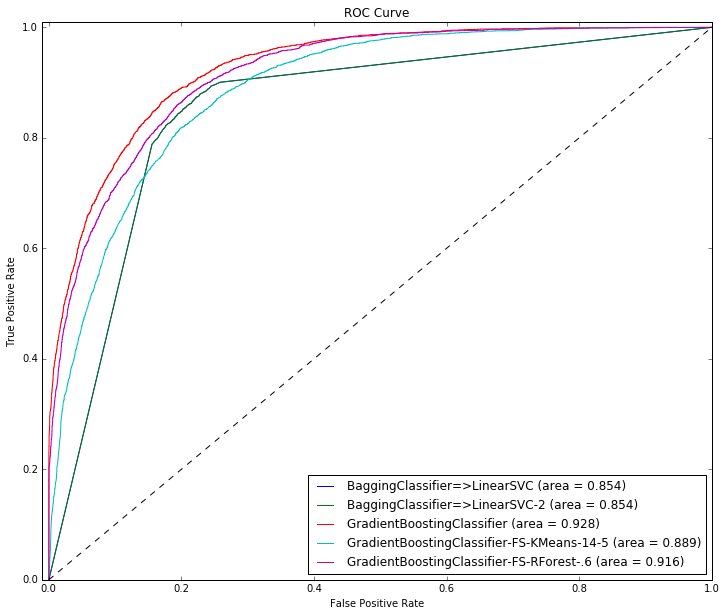

```python
Roc_Plot_Show()
```

# MLlib

This section begins simple examples of the pyspark mllib tree classifiers

```python
def Split_Train_Test_Mllib(dfL, normalize=False):
    global sc
    global trainData, testData

    # sc is existing SparkContext
    sqlContext = SQLContext(sc)

    # load a spark DF from existing pandas DF
    sdf = sqlContext.createDataFrame(dfL)

    # classification models require the use of LabeledPoint function for data format
    oridRDD = None

    if normalize:
        nor = Normalizer(1)
        origRDD = sdf.map(lambda x:LabeledPoint(x[0], nor.transform([x[1:]])))
    else:
        origRDD = sdf.map(lambda x:LabeledPoint(x[0], [x[1:]]))

    # split the data
    (trainData, testData) = origRDD.randomSplit([1-testSize, testSize])

    print 'Training Recs: ' , len(trainData.collect())
    print 'Testing Recs:  ' , len(testData.collect())
    return
```

```python
def Predict_Tree_Mllib(modelL):
    predictions = modelL.predict(testData.map(lambda x: x.features))

    labelsAndPredictions = testData.map(lambda lp: lp.label).zip(predictions)
    testErr = round(labelsAndPredictions.filter(lambda (v, p): v != p).count() / float(testData.count()),3)

    # Cross validation - need to research "spark.ml.tuning.CrossValidator" for this
    cvm = 'n/a'
    cvspm = 'n/a'

    print('Test Error = ' + str(testErr))
    #print(model.toDebugString())

    # Instantiate metrics object
    metrics = MulticlassMetrics(labelsAndPredictions)
    metrics2 = BinaryClassificationMetrics(labelsAndPredictions)

    # Overall summary statistics
    Sp = round(metrics.precision(),3)
    Sr = round(metrics.recall(),3)
    Sf1 = round(metrics.fMeasure(),3)

    cm = metrics.confusionMatrix().toArray()  # convert linalg.DenseVector to an array
    a = round((cm[0][0] + cm[1][1]) / (cm[0][0] + cm[0][1] + (cm[1][0] + cm[1][1])),3)

    roc = round(metrics2.areaUnderROC,3)
    aupr = round(metrics2.areaUnderPR,3)

    print
    print("Summary Stats:")
    print("Accuracy               = %s" % a)
    print("Precision              = %s" % Sp)
    print("Recall                 = %s" % Sr)
    print("F1 Score               = %s" % Sf1)
    print("Area under ROC         = %s" % roc)
    print("Area under PrecRecall  = %s" % aupr)

    print("\nConfusion Matrix:")
    print cm

    # Statistics by class
    print
    #labels = origRDD.map(lambda lp: lp.label).distinct().collect()
    labels = testData.map(lambda lp: lp.label).distinct().collect()
    for label in sorted(labels):
        print("Class %s precision  = %s" % (label, round(metrics.precision(label),3)))
        print("Class %s recall     = %s" % (label, round(metrics.recall(label),3)))
        print("Class %s F1 Measure = %s" % (label, round(metrics.fMeasure(label, beta=1.0),3)))

        # capture the statistics for the minority class in this case
        if label == 1.0:
            p = round(metrics.precision(label),3)
            r = round(metrics.recall(label),3)
            f1 = round(metrics.fMeasure(label, beta=1.0),3)

    # Weighted stats
    print
    print("Weighted recall              = %s" % round(metrics.weightedRecall,3))
    print("Weighted precision           = %s" % round(metrics.weightedPrecision,3))
    print("Weighted F(1) Score          = %s" % round(metrics.weightedFMeasure(),3))
    print("Weighted F(0.5) Score        = %s" % round(metrics.weightedFMeasure(beta=0.5),3))
    print("Weighted false positive rate = %s" % round(metrics.weightedFalsePositiveRate,3))
    print
    print modelL

    end = time.time()                             # end time
    elapsed = int(end - start)                    # elapsed time
    modelL_desc = str(modelL).split('(')[0]
    est = str(modelL).replace('\n','')
    dte = str(time.strftime("%y%m%d.%H:%M:%S"))   # date time stamp

    trainDataShape = len(trainData.collect())  # further investigate how to pull feature count

    Class_Results_Add([modelL_desc,est,cm,roc,a,cvm,cvspm,p,r,f1,trainDataShape,'None',Env,elapsed,dte])
    return
```

```python
Split_Train_Test_Mllib(df_std, normalize=False)    # df_std is already scaled by sklearn Scaler
```

```
Training Recs:  34138
Testing Recs:   14703
```

```python
# Decision Tree
start = time.time()        # capture start time
model = DecisionTree.trainClassifier(trainData, numClasses=2, categoricalFeaturesInfo={},
                                     impurity='gini', maxDepth=5, maxBins=32)
Predict_Tree_Mllib(model)
```

```
Test Error = 0.159

Summary Stats:
Accuracy               = 0.841
Precision              = 0.841
Recall                 = 0.841
F1 Score               = 0.841
Area under ROC         = 0.806
Area under PrecRecall  = 0.642

Confusion Matrix:
[[ 10641.   1776.]
 [   562.   1724.]]

Class 0.0 precision  = 0.95
Class 0.0 recall     = 0.857
Class 0.0 F1 Measure = 0.901
Class 1.0 precision  = 0.493
Class 1.0 recall     = 0.754
Class 1.0 F1 Measure = 0.596

Weighted recall              = 0.841
Weighted precision           = 0.879
Weighted F(1) Score          = 0.854
Weighted F(0.5) Score        = 0.867
Weighted false positive rate = 0.23

DecisionTreeModel classifier of depth 5 with 57 nodes
```

```python
# Random Forest
start = time.time()
model = RandomForest.trainClassifier(trainData, numClasses=2, categoricalFeaturesInfo={}, numTrees=300,
                                     featureSubsetStrategy="auto", impurity='gini', maxDepth=4, maxBins=32)
Predict_Tree_Mllib(model)
```

```
Test Error = 0.188

Summary Stats:
Accuracy               = 0.812
Precision              = 0.812
Recall                 = 0.812
F1 Score               = 0.812
Area under ROC         = 0.819
Area under PrecRecall  = 0.554

Confusion Matrix:
[[ 11006.   2562.]
 [   197.    938.]]

Class 0.0 precision  = 0.982
Class 0.0 recall     = 0.811
Class 0.0 F1 Measure = 0.889
Class 1.0 precision  = 0.268
Class 1.0 recall     = 0.826
Class 1.0 F1 Measure = 0.405

Weighted recall              = 0.812
Weighted precision           = 0.927
Weighted F(1) Score          = 0.851
Weighted F(0.5) Score        = 0.894
Weighted false positive rate = 0.175

TreeEnsembleModel classifier with 300 trees
```

```python
# Gradient Boosted Trees
start = time.time()
model = GradientBoostedTrees.trainClassifier(trainData, categoricalFeaturesInfo={}, loss='logLoss', numIterations=100,
                                     learningRate=0.1, maxDepth=3, maxBins=32)
Predict_Tree_Mllib(model)
```

```
Test Error = 0.141

Summary Stats:
Accuracy               = 0.859
Precision              = 0.859
Recall                 = 0.859
F1 Score               = 0.859
Area under ROC         = 0.823
Area under PrecRecall  = 0.698

Confusion Matrix:
[[ 10578.   1448.]
 [   625.   2052.]]

Class 0.0 precision  = 0.944
Class 0.0 recall     = 0.88
Class 0.0 F1 Measure = 0.911
Class 1.0 precision  = 0.586
Class 1.0 recall     = 0.767
Class 1.0 F1 Measure = 0.664

Weighted recall              = 0.859
Weighted precision           = 0.879
Weighted F(1) Score          = 0.866
Weighted F(0.5) Score        = 0.873
Weighted false positive rate = 0.213

TreeEnsembleModel classifier with 100 trees
```

```python
Grid_Results('Results_Grid')     # this also generates csv file for analysis
```

|  | Model | GridParms | GridBest | GridCVScore | Estimator | SearchPkg | TrainDta | FeatRed | Env | Sec | Date |
| --- | --- | --- | --- | --- | --- | --- | --- | --- | --- | --- | --- |
| 0 | LinearSVC | {u'C': [1.0, 1.5, 2.0, 2.5, 3.0, 3.5], u'intercept_scaling': [1, 1.5, 2], u'dual': [True, False]} | {u'C': 1.0, u'intercept_scaling': 1.5, u'dual': False} | 0.853 | LinearSVC(C=1.0, class_weight='balanced', dual=False, fit_intercept=True, intercept_scaling=1.5, loss='squared_hinge', max_iter=1000, multi_class='ovr', penalty='l2', random_state=42, tol=0.0001, verb… | sklearn | (34188, 108) | None | Docker | 685 | 160327.18:35:01 |
| 1 | LinearSVC | {u'C': [1.0, 1.5, 2.0, 2.5, 3.0, 3.5], u'intercept_scaling': [1, 1.5, 2], u'dual': [True, False]} | {u'C': 1.0, u'intercept_scaling': 1, u'dual': False} | 0.846 | LinearSVC(C=1.0, class_weight='balanced', dual=False, fit_intercept=True, intercept_scaling=1, loss='squared_hinge', max_iter=1000, multi_class='ovr', penalty='l2', random_state=42, tol=0.0001, verbos… | sklearn | (34188, 48) | -FS-KMeans-14-5 | Docker | 433 | 160327.18:42:46 |
| 2 | LinearSVC | {u'C': [1.0, 1.5, 2.0, 2.5, 3.0, 3.5], u'intercept_scaling': [1, 1.5, 2], u'dual': [True, False]} | {u'C': 1.0, u'intercept_scaling': 1, u'dual': False} | 0.851 | LinearSVC(C=1.0, class_weight='balanced', dual=False, fit_intercept=True, intercept_scaling=1, loss='squared_hinge', max_iter=1000, multi_class='ovr', penalty='l2', random_state=42, tol=0.0001, verbos… | sklearn | (34188, 64) | -FS-RForest-.6 | Docker | 458 | 160327.18:51:06 |
| 3 | GradientBoostingClassifier | {u'max_features': [0.25, 0.5, 0.75, None], u'n_estimators': [100], u'learning_rate': [0.1, 0.2, 0.3, 0.4, 0.5, 0.6, 0.7]} | {u'max_features': None, u'n_estimators': 100, u'learning_rate': 0.2} | 0.654 | GradientBoostingClassifier(init=None, learning_rate=0.20000000000000001, loss='deviance', max_depth=6, max_features=None, max_leaf_nodes=None, min_samples_leaf=1, min_samples_split=2, min_weight_fract… | sklearn | (34188, 108) | None | Docker | 840 | 160327.19:51:15 |
| 4 | GradientBoostingClassifier | {u'max_features': [0.25, 0.5, 0.75, None], u'n_estimators': [100], u'learning_rate': [0.1, 0.2, 0.3, 0.4, 0.5, 0.6, 0.7]} | {u'max_features': 0.5, u'n_estimators': 100, u'learning_rate': 0.1} | 0.572 | GradientBoostingClassifier(init=None, learning_rate=0.10000000000000001, loss='deviance', max_depth=6, max_features=0.5, max_leaf_nodes=None, min_samples_leaf=1, min_samples_split=2, min_weight_fracti… | sklearn | (34188, 48) | -FS-KMeans-14-5 | Docker | 454 | 160327.20:02:18 |
| 5 | GradientBoostingClassifier | {u'max_features': [0.25, 0.5, 0.75, None], u'n_estimators': [100], u'learning_rate': [0.1, 0.2, 0.3, 0.4, 0.5, 0.6, 0.7]} | {u'max_features': None, u'n_estimators': 100, u'learning_rate': 0.2} | 0.628 | GradientBoostingClassifier(init=None, learning_rate=0.20000000000000001, loss='deviance', max_depth=6, max_features=None, max_leaf_nodes=None, min_samples_leaf=1, min_samples_split=2, min_weight_fract… | sklearn | (34188, 64) | -FS-RForest-.6 | Docker | 591 | 160327.20:13:43 |

## Results of all classifiers

```python
Class_Results('Results_Class')   # this also generates csv file for analysis
```

|  | Model | Estimator | ConfMatrix | Roc | A | CVMean | CVspMean | P | R | F1 | TrainDta | FeatRed | Env | Sec | Date |
| --- | --- | --- | --- | --- | --- | --- | --- | --- | --- | --- | --- | --- | --- | --- | --- |
| 6 | GradientBoostingClassifier | GradientBoostingClassifier(init=None, learning_rate=0.20000000000000001, loss='deviance', max_depth=6, max_features=None, max_leaf_nodes=None, min_samples_leaf=1, min_samples_split=2, min_weight_fract… | [[10517, 649], [1190, 2297]] | 0.928 | 0.874 | 0.87 | 0.653 | 0.780 | 0.659 | 0.714 | (34188, 108) |  | Docker | 188 | 160327.19:54:24 |
| 8 | GradientBoostingClassifier | GradientBoostingClassifier(init=None, learning_rate=0.20000000000000001, loss='deviance', max_depth=6, max_features=None, max_leaf_nodes=None, min_samples_leaf=1, min_samples_split=2, min_weight_fract… | [[10424, 742], [1271, 2216]] | 0.916 | 0.863 | 0.86 | 0.63 | 0.749 | 0.636 | 0.688 | (34188, 64) | -FS-RForest-.6 | Docker | 135 | 160327.20:15:59 |
| 11 | TreeEnsembleModel classifier with 100 trees\n | TreeEnsembleModel classifier with 100 trees | [[10578.0, 1448.0], [625.0, 2052.0]] | 0.823 | 0.859 | n/a | n/a | 0.586 | 0.767 | 0.664 | 34138 | None | Docker | 377 | 160327.20:24:15 |
| 9 | DecisionTreeModel classifier of depth 5 with 57 nodes | DecisionTreeModel classifier of depth 5 with 57 nodes | [[10641.0, 1776.0], [562.0, 1724.0]] | 0.806 | 0.841 | n/a | n/a | 0.493 | 0.754 | 0.596 | 34138 | None | Docker | 52 | 160327.20:17:01 |
| 7 | GradientBoostingClassifier | GradientBoostingClassifier(init=None, learning_rate=0.10000000000000001, loss='deviance', max_depth=6, max_features=0.5, max_leaf_nodes=None, min_samples_leaf=1, min_samples_split=2, min_weight_fracti… | [[10279, 887], [1499, 1988]] | 0.889 | 0.837 | 0.837 | 0.567 | 0.691 | 0.570 | 0.625 | (34188, 48) | -FS-KMeans-14-5 | Docker | 64 | 160327.20:03:22 |
| 10 | TreeEnsembleModel classifier with 300 trees\n | TreeEnsembleModel classifier with 300 trees | [[11006.0, 2562.0], [197.0, 938.0]] | 0.819 | 0.812 | n/a | n/a | 0.268 | 0.826 | 0.405 | 34138 | None | Docker | 49 | 160327.20:17:55 |
| 0 | LinearSVC | LinearSVC(C=1.0, class_weight='balanced', dual=False, fit_intercept=True, intercept_scaling=1.5, loss='squared_hinge', max_iter=1000, multi_class='ovr', penalty='l2', random_state=42, tol=0.0001, verb… | [[8887, 2279], [507, 2980]] | 0.000 | 0.810 | 0.805 | 0.854 | 0.567 | 0.855 | 0.681 | (34188, 108) |  | Docker | 10 | 160327.18:35:12 |
| 3 | BaggingClassifier | BaggingClassifier(base_estimator=LinearSVC(C=1.0, class_weight='balanced', dual=False, fit_intercept=True, intercept_scaling=1.5, loss='squared_hinge', max_iter=1000, multi_class='ovr', penalty='l2', … | [[8891, 2275], [514, 2973]] | 0.854 | 0.810 | 0.805 | 0.853 | 0.567 | 0.853 | 0.681 | (34188, 108) | =>LinearSVC | Docker | 1399 | 160327.19:14:33 |
| 4 | LinearSVC | LinearSVC(C=2.5, class_weight='balanced', dual=False, fit_intercept=True, intercept_scaling=1, loss='squared_hinge', max_iter=1000, multi_class='ovr', penalty='l2', random_state=42, tol=0.0001, verbos… | [[8887, 2279], [507, 2980]] | 0.000 | 0.810 | 0.805 | 0.854 | 0.567 | 0.855 | 0.681 | (34188, 108) |  | Docker | 9 | 160327.19:14:42 |
| 5 | BaggingClassifier | BaggingClassifier(base_estimator=LinearSVC(C=2.5, class_weight='balanced', dual=False, fit_intercept=True, intercept_scaling=1, loss='squared_hinge', max_iter=1000, multi_class='ovr', penalty='l2', ra… | [[8891, 2275], [514, 2973]] | 0.854 | 0.810 | 0.805 | 0.853 | 0.567 | 0.853 | 0.681 | (34188, 108) | =>LinearSVC-2 | Docker | 1352 | 160327.19:37:14 |
| 2 | LinearSVC | LinearSVC(C=1.0, class_weight='balanced', dual=False, fit_intercept=True, intercept_scaling=1, loss='squared_hinge', max_iter=1000, multi_class='ovr', penalty='l2', random_state=42, tol=0.0001, verbos… | [[8722, 2444], [517, 2970]] | 0.000 | 0.798 | 0.793 | 0.851 | 0.549 | 0.852 | 0.667 | (34188, 64) | -FS-RForest-.6 | Docker | 7 | 160327.18:51:13 |
| 1 | LinearSVC | LinearSVC(C=1.0, class_weight='balanced', dual=False, fit_intercept=True, intercept_scaling=1, loss='squared_hinge', max_iter=1000, multi_class='ovr', penalty='l2', random_state=42, tol=0.0001, verbos… | [[8374, 2792], [518, 2969]] | 0.000 | 0.774 | 0.77 | 0.848 | 0.515 | 0.851 | 0.642 | (34188, 48) | -FS-KMeans-14-5 | Docker | 6 | 160327.18:42:53 |